# Final Project

Sarah

8/17/2019

# Synopsis

In this report I will be creating a model to predict 5 different exercises from the results of sensors on 6 participants. The data was taken from accelerometers on the belt, forearm, arm, and dumbbell.

The data for this project come from this source: http://web.archive.org/web/20161224072740/http:/groupware.les.inf.puc-rio.br/har.

# How I Built My Model

### Load the data into R

The caret package is used in the process

```r
set.seed(123)
library(caret)
training = read.csv("~/Desktop/pml-training.csv", na.strings=c("","#DIV/0!","NA"))
testing = read.csv("~/Desktop/pml-testing.csv")
dim(training)
```

```
## [1] 19622   160
```

In this situation, I considered a no value “” and “#DIV/0!” to also excluded as an NA value.

```r
table(colSums(is.na(training)))
```

```
##
##     0 19216 19217 19218 19220 19221 19225 19226 19227 19248 19293 19294
##    60    67     1     1     1     4     1     4     2     2     1     1
## 19296 19299 19300 19301 19622
##     2     1     4     2     6
```

```r
new<-training[, colSums(is.na(training))<10000]

sum(is.na(new))
```

```
## [1] 0
```

Now there are no NA values left in the data and will make it much easier to create a model

I changed all columns to numeric to further simplify the process.

```r
table(sapply(new, class)) ##old classes
```

```
##
##  factor integer numeric
##       4      29      27
```

```r
dfnum<-function(mydat){
    for (i in 1:60){
        mydat[[i]]<-as.numeric(mydat[[i]])      }
    mydat
}

new<-dfnum(new) ##changed all columns to be numeric class
table(sapply(new, class))
```

```
##
## numeric
##      60
```

I checked to see if there was correlation between the X variable and classe variable by plotting it

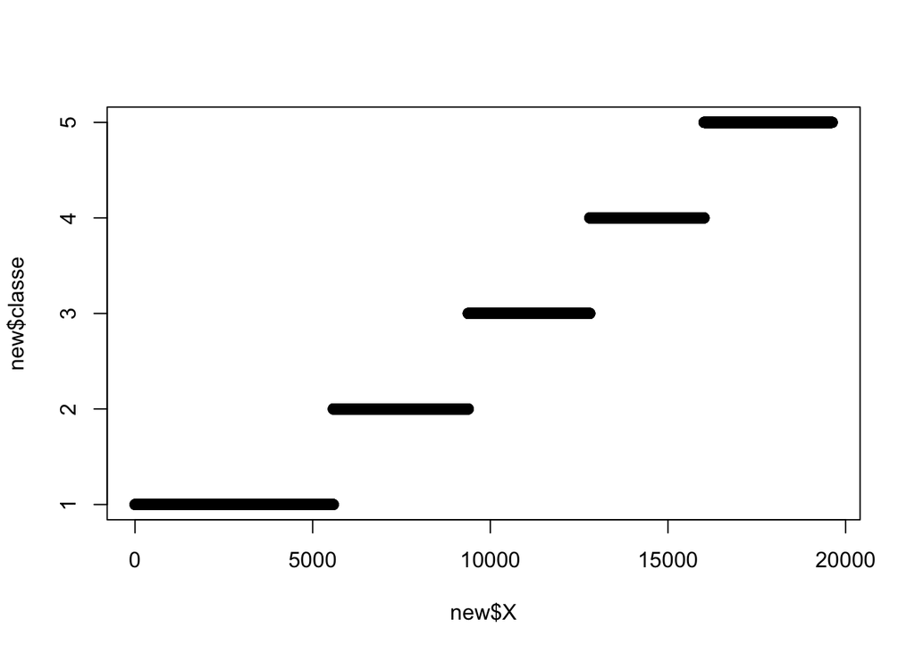

```r
plot(new$X, new$classe)
```

There is a high correlation and since I don’t want the model to be correlated with the number of the question, I removed the X variable.

```r
new<-new[-1] ##Remove the X variable
```

Then, I separated the data into a training and a validation set so that I can check my results.

```r
inBuild<-createDataPartition(y = new$classe,p=0.7, list = FALSE)
validation<-new[-inBuild,]##Separate into validation and training sets
mytrain<-new[inBuild,]
```

### Random Forest Model

```r
x <- mytrain[,-59]
y <- mytrain[,59]

library(parallel)
library(doParallel)
mycluster <- makeCluster(detectCores() - 1)
registerDoParallel(mycluster)
fitControl <- trainControl(method = "cv",number = 2,allowParallel = TRUE)

rffit <- train(x,factor(y), method="rf",data=mytrain,trControl = fitControl)

stopCluster(mycluster)
registerDoSEQ()
rfpred<-predict(rffit, validation)
```

### Support Vector Machine Method:

```r
library(e1071)
svmfit<-svm(factor(classe)~.,data =mytrain)
svmpred<-predict(svmfit, validation)
```

### Linear Discriminant Analysis Method:

```r
ldafit<-train(factor(classe)~., method = "lda", data = mytrain)
ldapred<-predict(ldafit,validation)
```

Then I tested the different models against the validation test set to see which one performed the best.

```r
myvalid<-validation$classe

rfacc<-sum(myvalid==rfpred)/length(myvalid)
svmacc<-sum(myvalid==svmpred)/length(myvalid)
ldaacc<-sum(myvalid==ldapred)/length(myvalid)
myacc<-data.frame(rfacc,svmacc,ldaacc)
myacc
```

```
##       rfacc    svmacc    ldaacc
## 1 0.9996602 0.9423959 0.8164826
```

I had previously planned to use model stacking, but with an accuracy rate of above 99%, I decided it was high enough for this exercise and I will save the other calculations for a different project. I used the random forest model as my final model.

Here’s the resulting Confusion Matrix from using the random forest model on the validation set.

```r
confusionMatrix(rfpred,as.factor(validation$classe))
```

```
## Confusion Matrix and Statistics
##
##           Reference
## Prediction    1    2    3    4    5
##          1 1690    0    0    0    0
##          2    0 1091    0    0    0
##          3    0    0 1058    1    0
##          4    0    0    0  962    0
##          5    0    0    0    1 1082
##
## Overall Statistics
##
##                Accuracy : 0.9997
##                  95% CI : (0.9988, 1)
##     No Information Rate : 0.2872
##     P-Value [Acc > NIR] : < 2.2e-16
##
##                   Kappa : 0.9996
##
##  Mcnemar's Test P-Value : NA
##
## Statistics by Class:
##
##                      Class: 1 Class: 2 Class: 3 Class: 4 Class: 5
## Sensitivity            1.0000   1.0000   1.0000   0.9979   1.0000
## Specificity            1.0000   1.0000   0.9998   1.0000   0.9998
## Pos Pred Value         1.0000   1.0000   0.9991   1.0000   0.9991
## Neg Pred Value         1.0000   1.0000   1.0000   0.9996   1.0000
## Prevalence             0.2872   0.1854   0.1798   0.1638   0.1839
## Detection Rate         0.2872   0.1854   0.1798   0.1635   0.1839
## Detection Prevalence   0.2872   0.1854   0.1799   0.1635   0.1840
## Balanced Accuracy      1.0000   1.0000   0.9999   0.9990   0.9999
```

### Expected Out of Sample Error

We can expect that the out of sample error will be about the same as what it was when we tested it on the validation data set.

```r
myacc$rfacc
```

```
## [1] 0.9996602
```

```r
rfrmse<-sqrt(sum((as.numeric(rfpred)-myvalid)^2))
svrmse<-sqrt(sum((as.numeric(svmpred)-myvalid)^2))
ldarmse<-sqrt(sum((as.numeric(ldapred)-myvalid)^2))
myrmse<-data.frame(rfrmse,svrmse,ldarmse)
myrmse
```

```
##     rfrmse   svrmse  ldarmse
## 1 1.414214 23.60085 41.49699
```

### Conclusion

Thanks for the review!